# Graphically Based Data Analysis Using Flexplot

## Avoiding Overlap

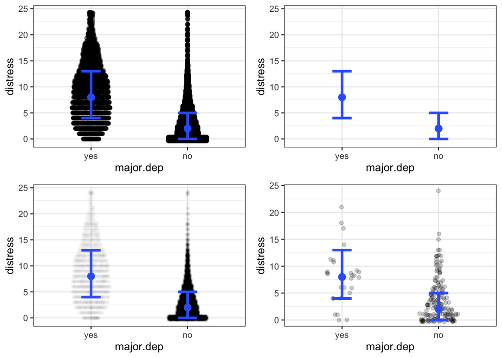

```r
data("nsduh")

a = flexplot(distress~major.dep, data=nsduh)
b = flexplot(distress~major.dep, data=nsduh, raw.data=F)
c = flexplot(distress~major.dep, data=nsduh, alpha=.005)
d = flexplot(distress~major.dep, data=nsduh, sample=200)

cowplot::plot_grid(a,b,c,d, nrow=2)
```

# Multivariate Graphics

Visualizing multivariate relationships can become quite tricky. It is very easy to experience cognitive overload, especially when one is attempting to visualize raw data (which is, again, a key characteristic of Flexplot). Some might be inclined to do three-dimensional plots. However, I find these difficult to interpret and they require the user to rotate the view. Even then, they can only show two two predictors at a time. I find it much easier to use other strategies. `flexplot()` utilizes four different strategies to visualize multivariate relationships: (1) plotting a dimension as different colors/lines/shapes, (2) plotting a dimension in row or column panels, (3) visualize conditional relationships with added variable plots, and (4) overlaying ghost lines.